# jmariaguirre-PAC3

Jesus Mari Aguirre

1/11/2017

## Pregunta 2.

En aquest exercici aneu a seguir els passos del cicle de vida d’un projecte de mineria de dades pel cas d’un algorisme de classificació i més concretament un arbre de decisió. Ho fareu amb el fitxer titanic.csv. Que trobareu a la wiki. Aquest fitxer conté un registre per cada passatger que viatjava en el Titànic. En les variables es caracteritza si era home o dona, adult o nen, en quina categoria viatjava o si era membre de la tripulació.

### Estudieu les dades.

per exemple: Número de registres dels fitxer? Distribucions de valors per variables? Hi ha camps mal informats o buits?

```r
passatgers<-read.csv("/Users/jmari/Dropbox/Master Ciencia de les dades/mineria de dades/PAC3/titanic.csv",header=TRUE,na.strings = "NA")
```

Examinem el contingut, totes les columnes són categòriques, són completes i els valors que prenen són raonables.

```r
str(passatgers)
```

```
## 'data.frame':    2201 obs. of  4 variables:
##  $ CLASS   : Factor w/ 4 levels "1a","2a","3aa",..: 1 1 1 1 1 1 1 1 1 1 ...
##  $ AGE     : Factor w/ 2 levels "Adult","Nen": 1 1 1 1 1 1 1 1 1 1 ...
##  $ SEX     : Factor w/ 2 levels "Dona","Home": 2 2 2 2 2 2 2 2 2 2 ...
##  $ SURVIVED: Factor w/ 2 levels "Mor","Sobreviu": 2 2 2 2 2 2 2 2 2 2 ...
```

Examinem el sumari, a on podem veure que no hi ha cap columna amb valors NA i les categories.

```r
summary(passatgers)
```

```
##   CLASS        AGE         SEX           SURVIVED
##  1a  :325   Adult:2092   Dona: 470   Mor     :1490
##  2a  :285   Nen  : 109   Home:1731   Sobreviu: 711
##  3aa :706
##  crew:885
```

### Prepareu les dades.

En aquest cas ja estan en el format correcte i no cal discretitzar ni generar atributs nous. Cal triar quines són les variables que s’utilitzaran per construir el model i quina és la variable que classifica. En aquest cas la variable per la que classificarem és el camp de si el passatger va sobreviure o no.

Per a poder dur a terme aquest apartat, primer de tot instal·lam el paquet C50 i inclourem la libreria C50 a la sessió fent:

```r
#install.packages("C50")
#install.packages("gmodels")
library(C50)
library(gmodels)
```

Partint d’aquest conjunt de dades crearem dos subconjunts, un per a la creació del model i altre per testà aquest model:

```r
indexes = sample(2201,1000)
passatgers.train = passatgers[indexes,]
passatgers.test = passatgers[-indexes,]
```

### Creació del model

Per a crear el model, triem les columnes CLASS, AGE i SEX, i classifiquem per SURVIVED. crearem dues matrius, trainX i trainY per passar-les com argument a la funció C50::C5.0

```r
trainX <-passatgers.train[,c("CLASS","AGE","SEX")]
trainY <-passatgers.train[,c("SURVIVED")]
passatgers.model <- C50::C5.0( trainX, trainY )
summary( passatgers.model )
```

```
##
## Call:
## C5.0.default(x = trainX, y = trainY)
##
##
## C5.0 [Release 2.07 GPL Edition]      Sat Nov  4 09:24:36 2017
## -------------------------------
##
## Class specified by attribute `outcome'
##
## Read 1000 cases (4 attributes) from undefined.data
##
## Decision tree:
##
## SEX = Home: Mor (783/164)
## SEX = Dona:
## :...CLASS in {1a,2a,crew}: Sobreviu (132/7)
##     CLASS = 3aa: Mor (85/37)
##
##
## Evaluation on training data (1000 cases):
##
##      Decision Tree
##    ----------------
##    Size      Errors
##
##       3  208(20.8%)   <<
##
##
##     (a)   (b)    <-classified as
##    ----  ----
##     667     7    (a): class Mor
##     201   125    (b): class Sobreviu
##
##
##  Attribute usage:
##
##  100.00% SEX
##   21.70% CLASS
##
##
## Time: 0.0 secs
```

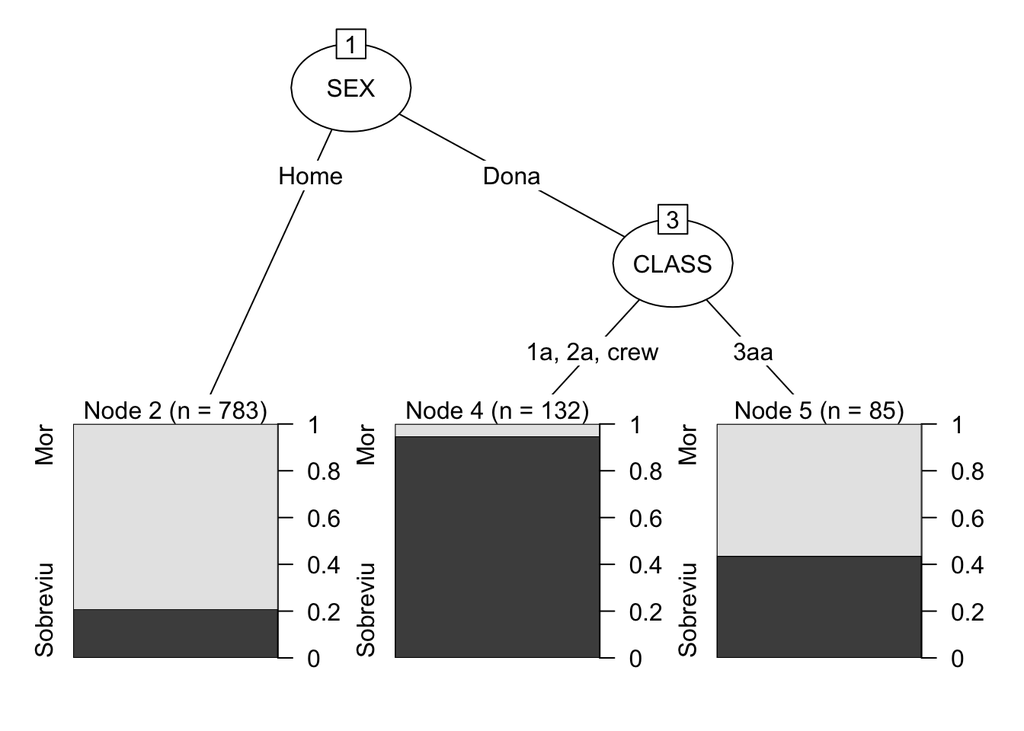

```r
plot(passatgers.model)
```

Les regles serien:

SEX = Home => Mor SEX = Dona & CLASS pertany[1a,2a,crew] => Sobreviu SEX = Dona & CLASS = 3aa => Mor

Provem de generar un model fent trials=10 i veure si obtenim un resultat mijor. Veurém que obtenim un subconjunt amb un error menor, però amb les mateixes regles.

```r
passatgers.model <- C50::C5.0( trainX, trainY, trials=10 )
summary( passatgers.model )
```

[output not shown]

### Avaluació del model

Probarem de fer la predicció amb el model obtingut, damunt del subconjunt de test

```r
passatgers.predict <- predict.C5.0(passatgers.model, passatgers.test)
CrossTable(passatgers.predict,passatgers.test$SURVIVED)
```

```
##
##
##    Cell Contents
## |-------------------------|
## |                       N |
## | Chi-square contribution |
## |           N / Row Total |
## |           N / Col Total |
## |         N / Table Total |
## |-------------------------|
##
##
## Total Observations in Table:  1201
##
##
##                    | passatgers.test$SURVIVED
## passatgers.predict |       Mor |  Sobreviu | Row Total |
## -------------------|-----------|-----------|-----------|
##                Mor |       803 |       256 |      1059 |
##                    |     9.685 |    20.528 |           |
##                    |     0.758 |     0.242 |     0.882 |
##                    |     0.984 |     0.665 |           |
##                    |     0.669 |     0.213 |           |
## -------------------|-----------|-----------|-----------|
##           Sobreviu |        13 |       129 |       142 |
##                    |    72.231 |   153.093 |           |
##                    |     0.092 |     0.908 |     0.118 |
##                    |     0.016 |     0.335 |           |
##                    |     0.011 |     0.107 |           |
## -------------------|-----------|-----------|-----------|
##       Column Total |       816 |       385 |      1201 |
##                    |     0.679 |     0.321 |           |
## -------------------|-----------|-----------|-----------|
##
##
```